# Bottom-up effects of woodland eutrophication: Interacting limiting nutrients determine herbivory frequency in northwestern Patagonia - ScienceDirect

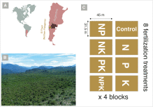

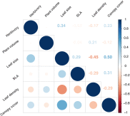

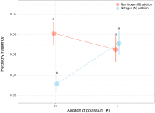

## [Science of The Total Environment](https://www.sciencedirect.com/science/journal/00489697)

Available online 12 November 2021, 151608

[In Press, Corrected Proof](https://www.sciencedirect.com/science/journal/aip/00489697)

# Bottom-up effects of woodland eutrophication: Interacting limiting nutrients determine herbivory frequency in northwestern Patagonia

[N.Pérez-Méndez<sup>a</sup>](https://www.sciencedirect.com/science/article/abs/pii/S0048969721066845#!)[M.M.Fernández<sup>b</sup><sup>c</sup><sup>d</sup>](https://www.sciencedirect.com/science/article/abs/pii/S0048969721066845#!)[L.van Doorn<sup>b</sup><sup>c</sup><sup>e</sup>](https://www.sciencedirect.com/science/article/abs/pii/S0048969721066845#!)[M.M.Català-Forner<sup>a</sup>](https://www.sciencedirect.com/science/article/abs/pii/S0048969721066845#!)[L.Martínez<sup>b</sup><sup>c</sup>](https://www.sciencedirect.com/science/article/abs/pii/S0048969721066845#!)[L.A.Garibaldi<sup>b</sup><sup>c</sup>](https://www.sciencedirect.com/science/article/abs/pii/S0048969721066845#!)

## Highlights

**•**

Effects of soil eutrophication on plant–herbivore interactions remains understudied.

**•**

Interactive effects of N, P, K addition on herbivory patterns were studied.

**•**

Nitrogen soil enrichment reduced herbivory frequency by 41%.

**•**

Potassium addition buffered the effect of N-enrichment.

**•**

Effects of nutrient enrichment were mediated by changes in leaf density and leaf size.

## Abstract

[Nutrient enrichment](https://www.sciencedirect.com/topics/earth-and-planetary-sciences/nutrient-enrichment) disrupts plant–animal interactions and ecosystem functioning globally. In woodland systems, the mechanisms of bottom-up turnover on plant*–*herbivore interactions remain understudied. Here, we performed a full-factorial field experiment to evaluate the interactive effects of nutrient addition (nitrogen, phosphorus, and/or potassium) on the assemblage of foliar herbivores and the interaction frequency with *Berberis microphylla*, a dominant shrub species in Patagonian woodlands. Additionally, we assessed whether these effects could be mediated by changes in vegetative traits and microhabitat characteristics (i.e., canopy cover) that may ultimately influence the [foraging behavior](https://www.sciencedirect.com/topics/earth-and-planetary-sciences/foraging-behavior) of herbivores. The addition of nitrogen reduced the herbivory frequency by 41%, yet this effect was diluted in the presence of potassium. We found no effects of phosphorus addition. Our results suggest that the impact of multiple nutrient additions (N and K) on herbivory patterns could be mediated by changes in two important foliar traits, leaf size and leaf density. This study shows how multiple nutrient addition can change the magnitude of antagonistic plant–animal interactions in woodlands. Since herbivory by arthropods has a relevant role in net primary productivity, our results highlight the importance of buffering human-driven woodland eutrophication to maintain important ecological functions (e.g., herbivory) associated with antagonistic plant–animal interactions and avoiding ecosystem dysfunction.

## Graphical abstract

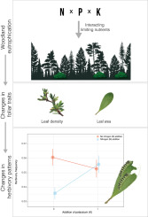

## Keywords

Eutrophication

Herbivores

Nitrogen

Potassium

Phosphorus

Patagonia

© 2021 Elsevier B.V. All rights reserved.